# Gender Quotas - Pilot 2

Ale & Juan

2025-01-31

# Between Subjects

## Absolute Offers

The effect in the 1st Round is very evident. It is not as strong in the rest of the rounds, but this doesn’t control for the effect of performance.

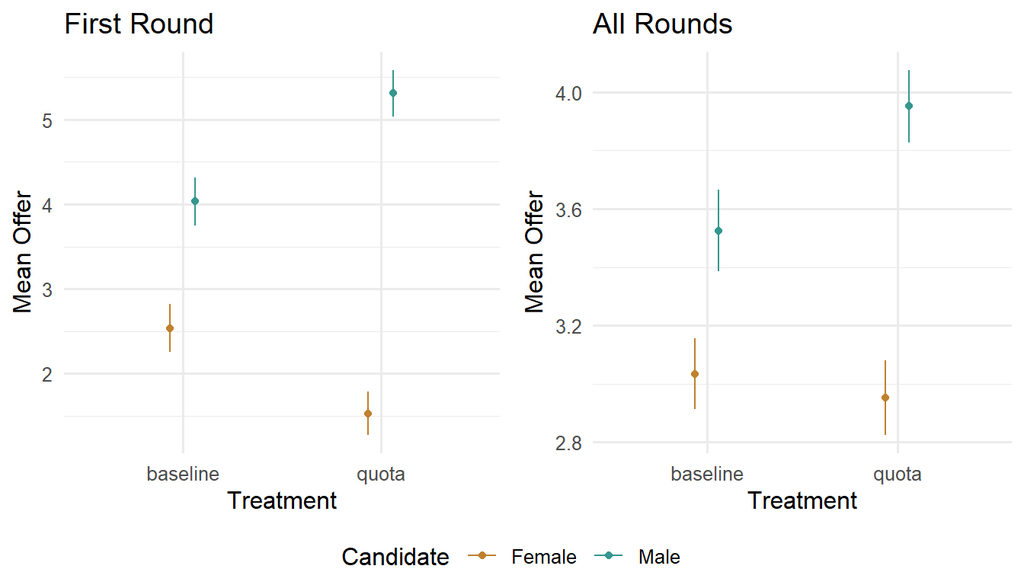

Importantly, imposing quotas doesn’t affect offers when both candidates are either male or female. However, it has a strong effect when comparing between candidates of different genders.

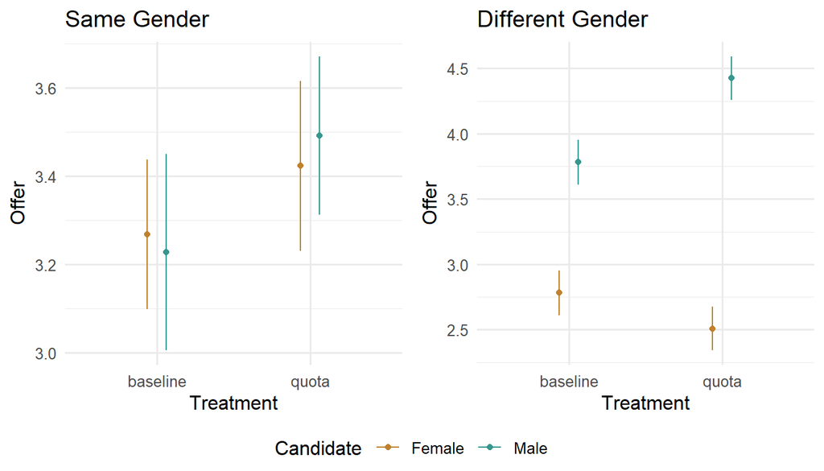

The treatment effect is significant, even when considering only people who allocated the entire budget (attention check). Standard errors in all regressions are clustered at the individual.

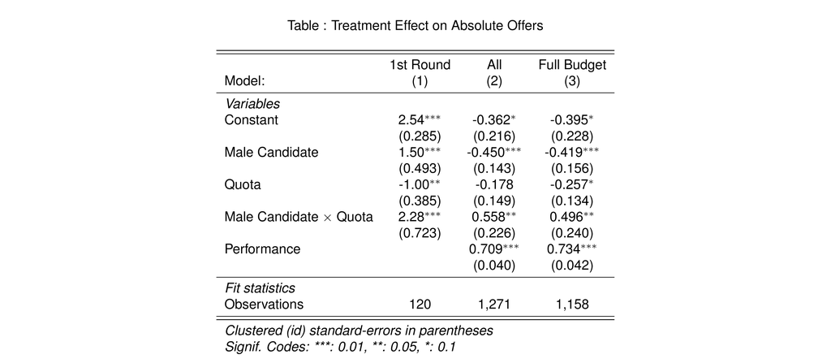

Raw distributions:

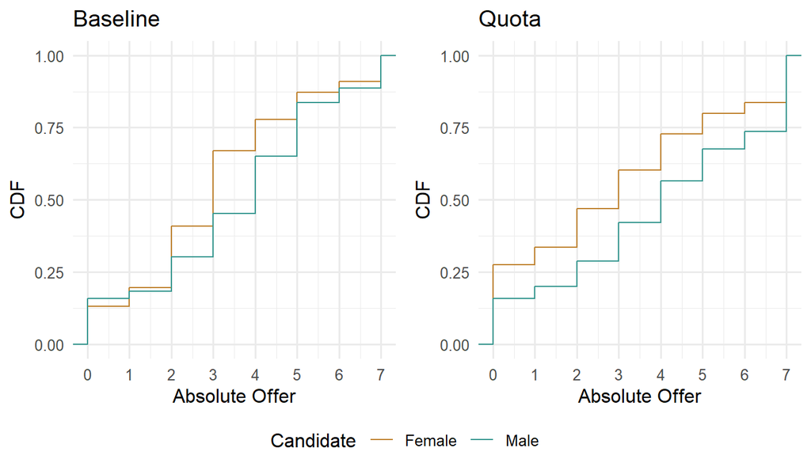

## Adjusted Offers

To control better for the role of performance on offers, I define Adjusted Offers as Offer/Performance. The results are even more clear:

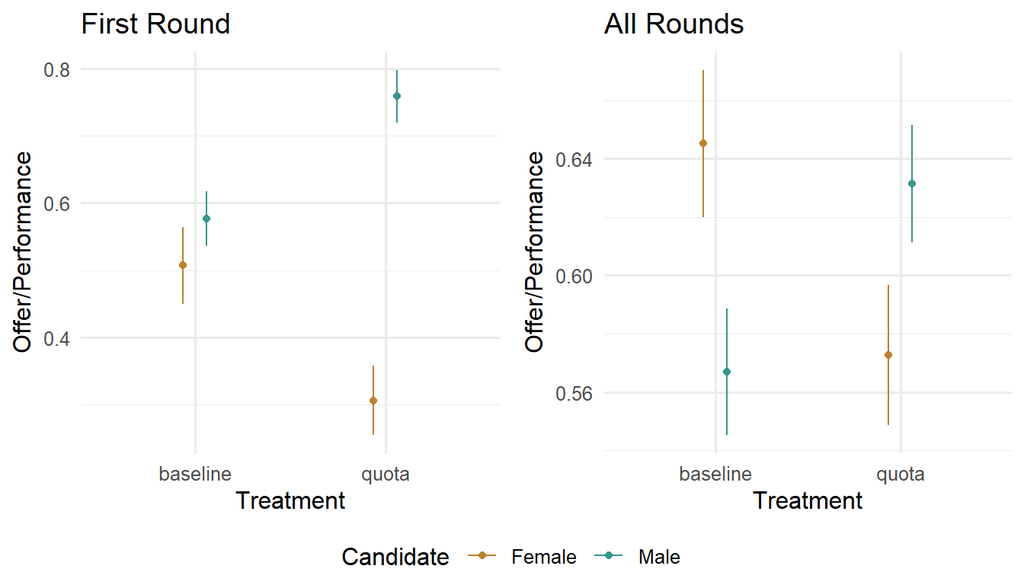

Again, no effect among candidates of the same gender, but a huge effect on pairs of candidates of different sex. I find this graph **amazing**.

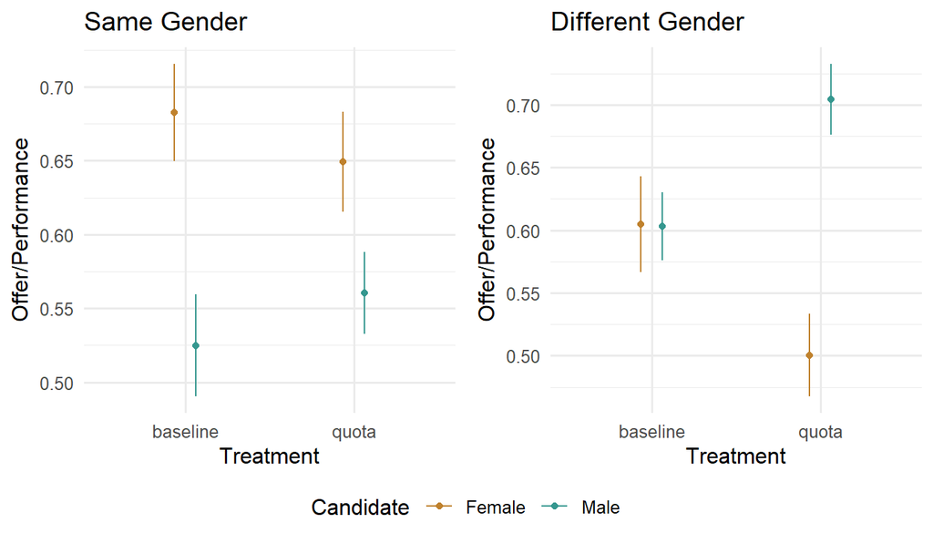

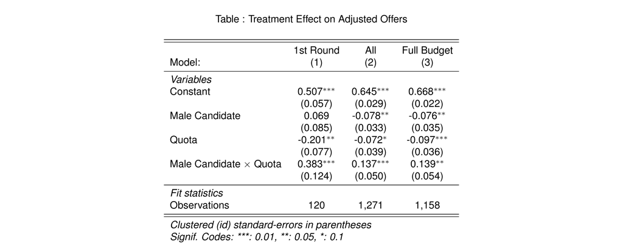

Raw distributions:

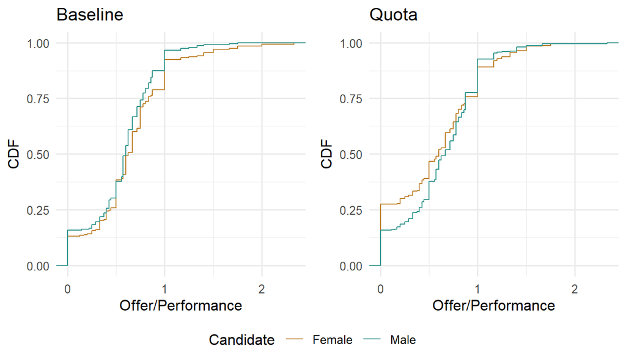

## Heterogeneity

The Quota effect seems driven by female participants. It is also more pronounced among Conservatives.

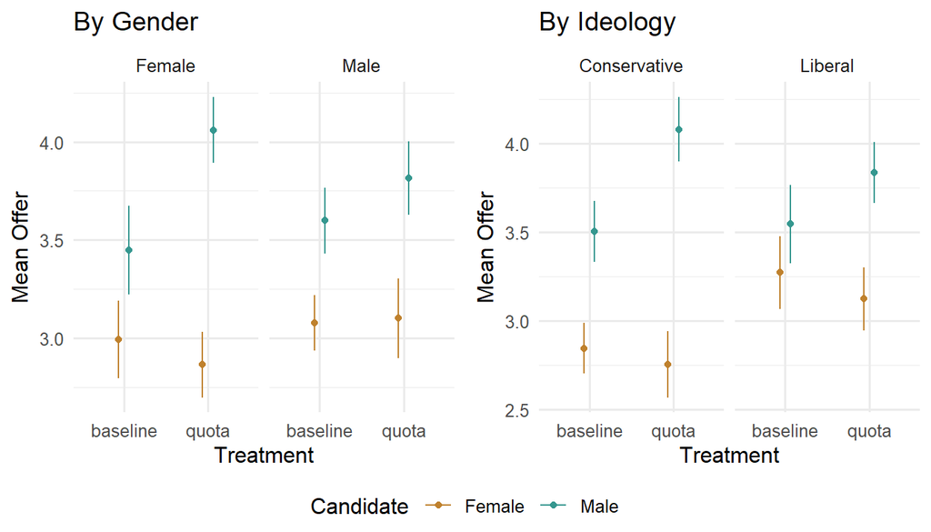

Again, the effect is clear: when quotas are introduced, more is offered to men and less to women. This is true both when considering absolute offers (controling for performance) and when considering offers adjusted by performance.

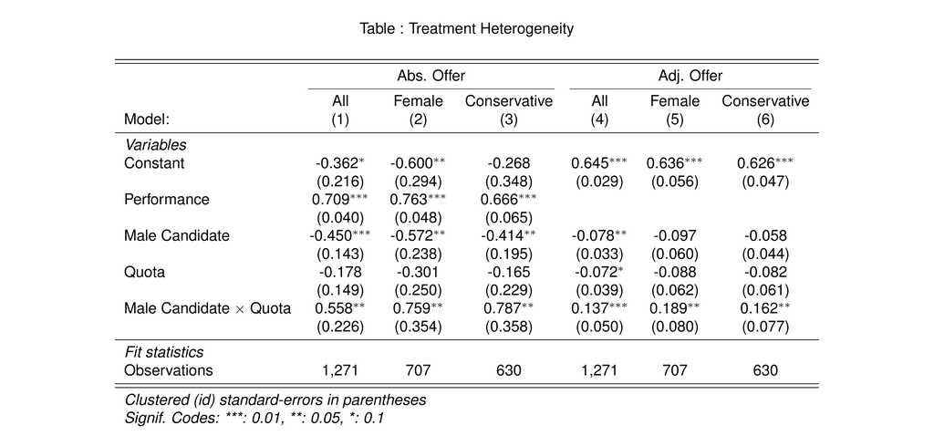

## Extensive Margin

Imposing quotas has a significant effect on the extensive margin: when quotas are in force, more female candidates receive an offer of $0. This is not driven by the performance of female candidates being worse in the Quota Treatment by chance.

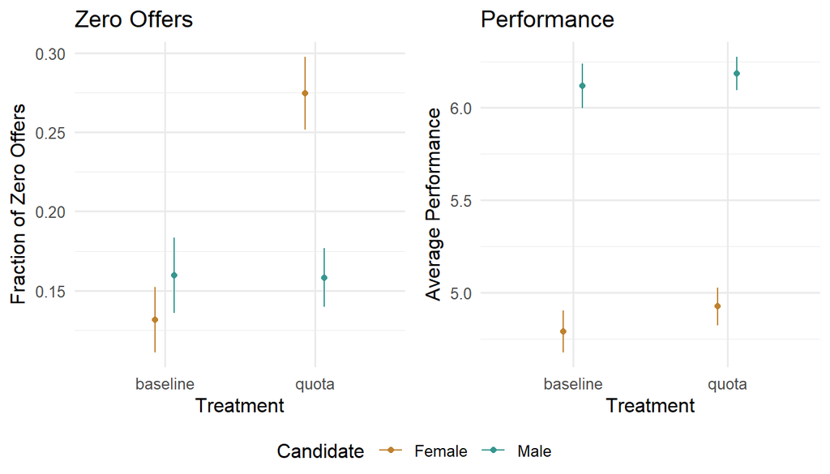

The effect on the extensive margin is highly significant: quotas increase the probability of a female candidate not receiving an offer by 15pp (by >100%!!). This effect is more pronounced among Conservatives.

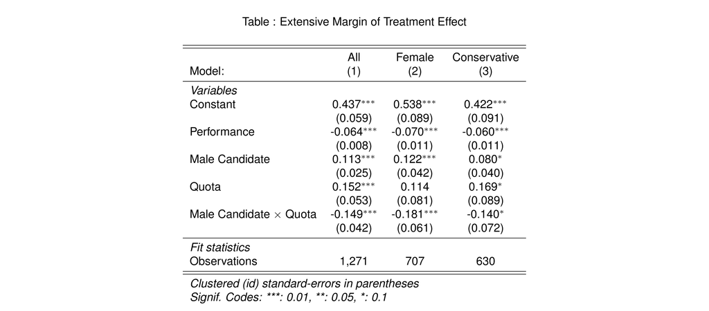

## Evolution

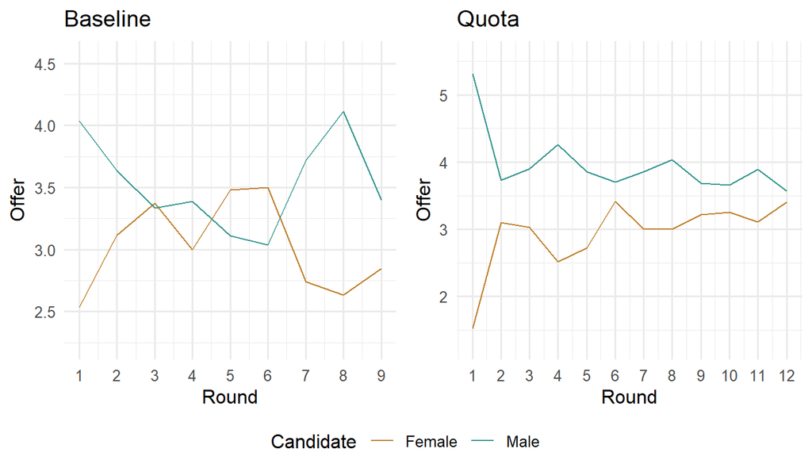

# Within Subjects

If anything, we observe the opposite of the expected treatment effect.

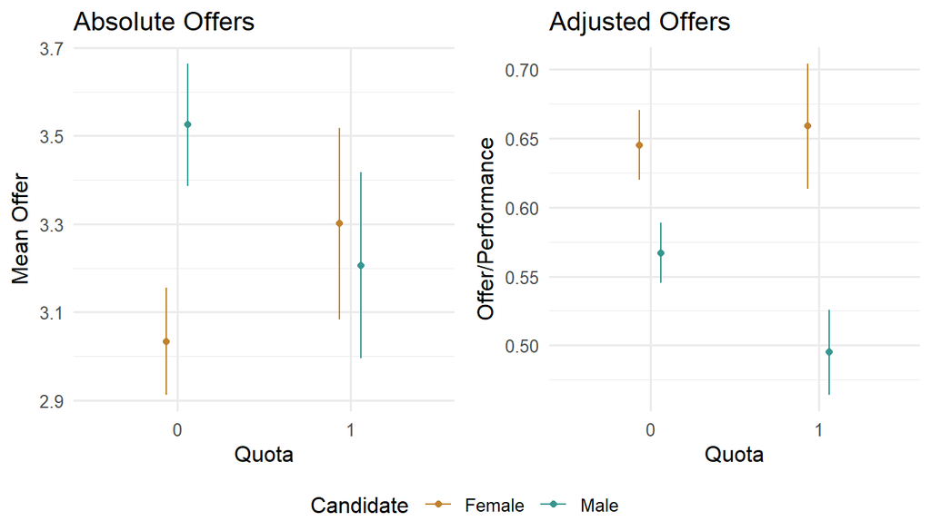

# Predictions

No quota effect. People over estimate the performance of male candidates and under estimate it for female candidates.

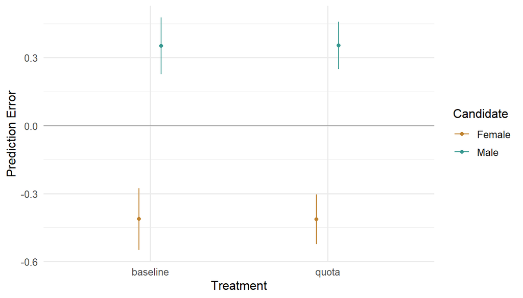

## Heterogeneity

Quotas reduce perceived performance of all candidates for Conservative men, and increase it for Conservative women. No effect for Liberals.

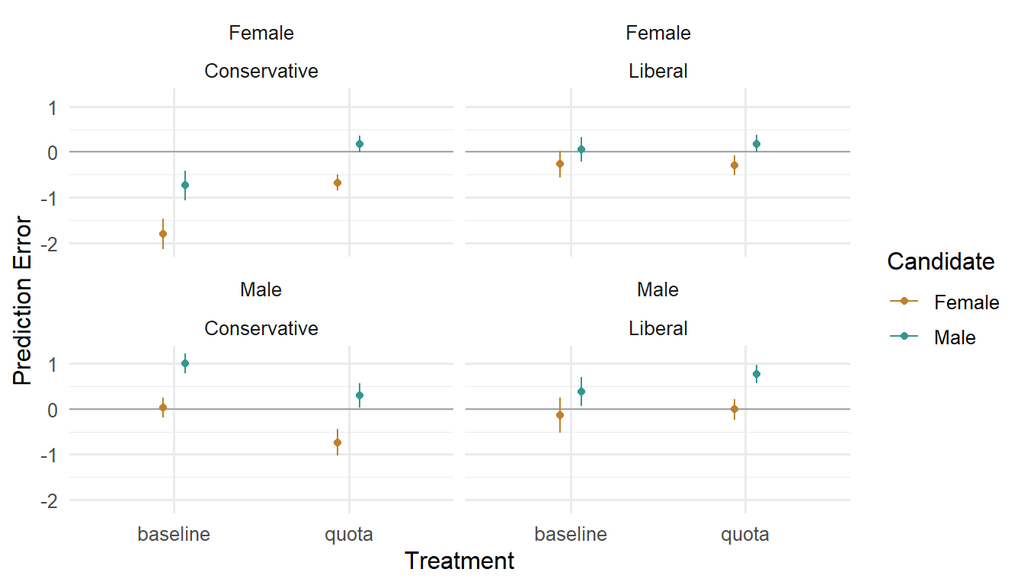

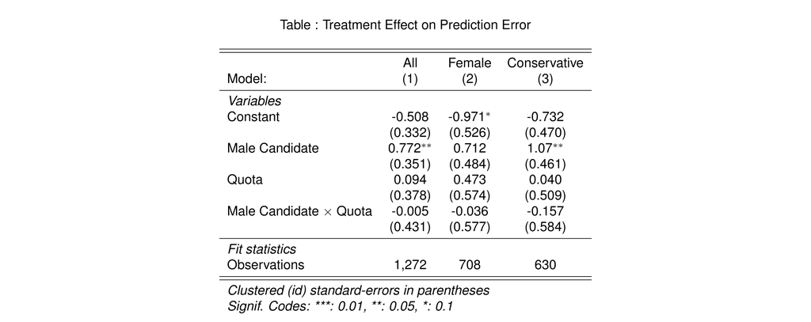

# Final Survey

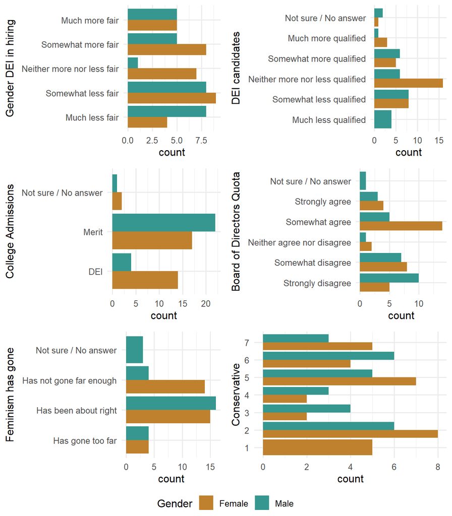

## Treatment Heterogeneity

Surprisingly, across the board, the effect is more apparent among the people who are **not opposed** to quotas and DEI.

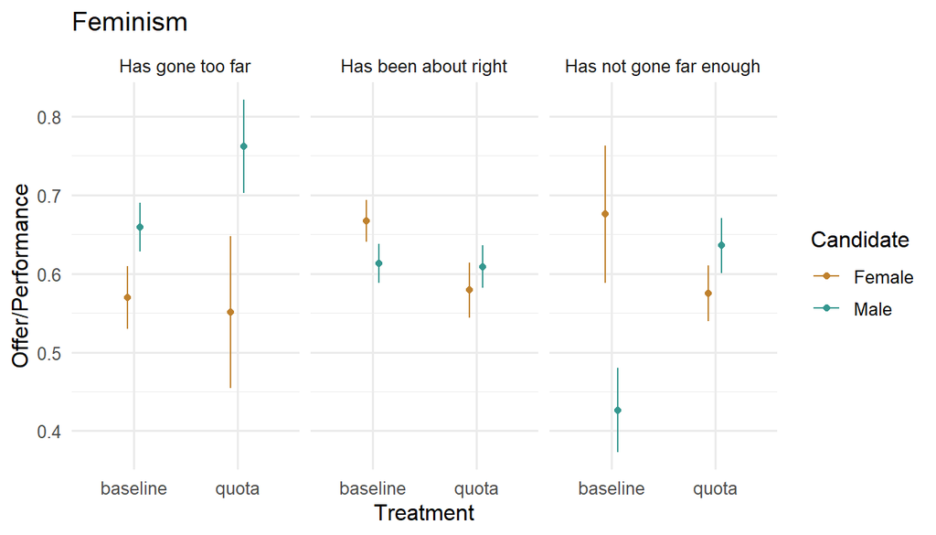

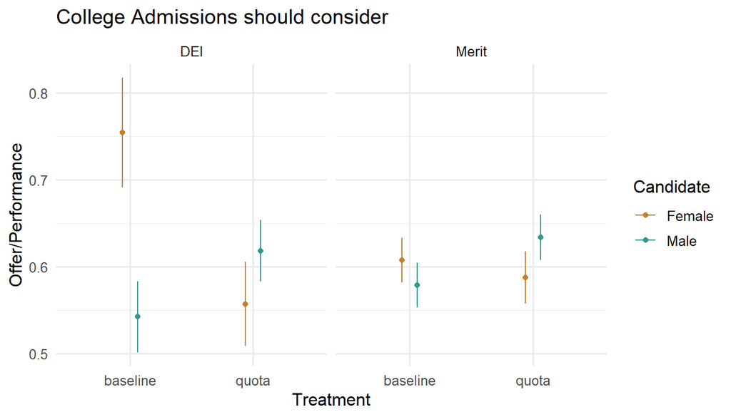

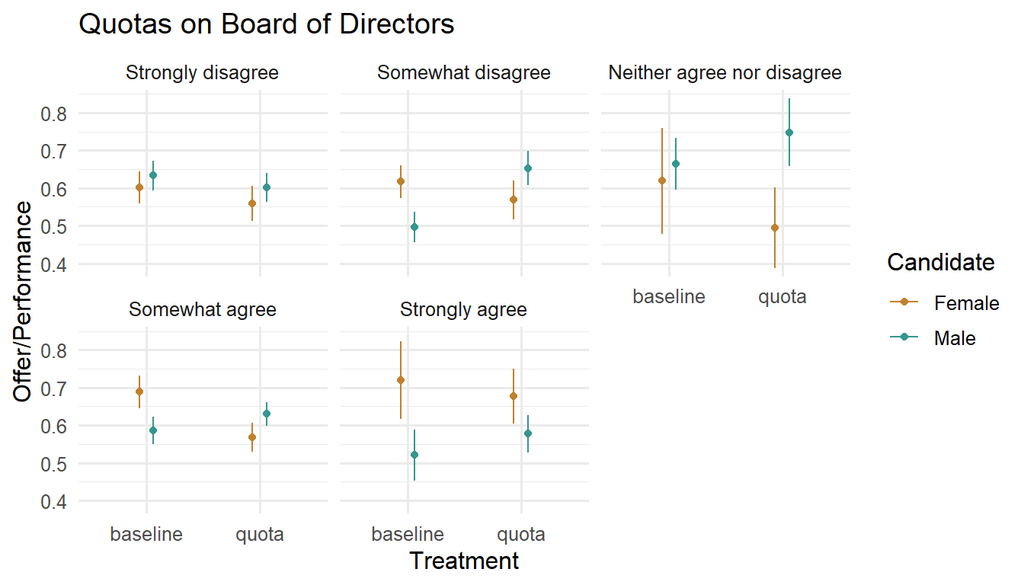

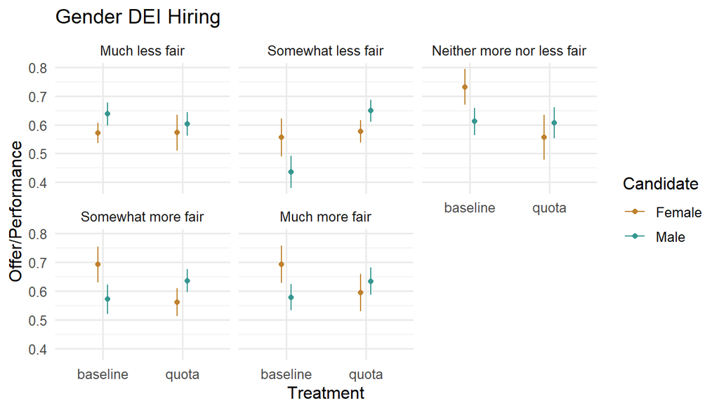